# Problem 1:

Given some sample data, write a program to answer the following: [click here to access the required data set](https://docs.google.com/spreadsheets/d/16i38oonuX1y1g7C_UAmiK9GkY7cS-64DfiDMNiR41LM/edit#gid=0)

On Shopify, we have exactly 100 sneaker shops, and each of these shops sells only one model of shoe. We want to do some analysis of the average order value (AOV). When we look at orders data over a 30 day window, we naively calculate an AOV of $3145.13. Given that we know these shops are selling sneakers, a relatively affordable item, something seems wrong with our analysis.

- Think about what could be going wrong with our calculation. Think about a better way to evaluate this data.
- What metric would you report for this dataset?
- What is its value?

# Solution:

The Key Data columns to focus on in this dataset are the **order_amount** and **total_items** column. I imported the dataset to investigate further.

```python
import pandas as pd
import numpy as np
csv = pd.read_csv('/Users/ameyadalvi/Downloads/shopifydata.csv')
shopify = pd.DataFrame(csv)
shopify
```

|  | order_id | shop_id | user_id | order_amount | total_items | payment_method | created_at |
| --- | --- | --- | --- | --- | --- | --- | --- |
| 0 | 1 | 53 | 746 | 224 | 2 | cash | 2017-03-13 12:36:56 |
| 1 | 2 | 92 | 925 | 90 | 1 | cash | 2017-03-03 17:38:52 |
| 2 | 3 | 44 | 861 | 144 | 1 | cash | 2017-03-14 4:23:56 |
| 3 | 4 | 18 | 935 | 156 | 1 | credit_card | 2017-03-26 12:43:37 |
| 4 | 5 | 18 | 883 | 156 | 1 | credit_card | 2017-03-01 4:35:11 |
| ... | ... | ... | ... | ... | ... | ... | ... |
| 4995 | 4996 | 73 | 993 | 330 | 2 | debit | 2017-03-30 13:47:17 |
| 4996 | 4997 | 48 | 789 | 234 | 2 | cash | 2017-03-16 20:36:16 |
| 4997 | 4998 | 56 | 867 | 351 | 3 | cash | 2017-03-19 5:42:42 |
| 4998 | 4999 | 60 | 825 | 354 | 2 | credit_card | 2017-03-16 14:51:18 |
| 4999 | 5000 | 44 | 734 | 288 | 2 | debit | 2017-03-18 15:48:18 |

5000 rows × 7 columns

Checking some distribution metrics and their values for the order_amount

```python
shopify["order_amount"].mean()
```

```
3145.128
```

```python
shopify["order_amount"].median()
```

```
284.0
```

```python
shopify["order_amount"].mode()
```

```
0    153
dtype: int64
```

```python
shopify["order_amount"].max()
```

```
704000
```

### The Issue:

- The problem statement's naive calculation of the average order value appears to be determined by averaging all order amounts in all stores over a 30-day period. (Sum of all order amounts / 5000 records)
- After digging deeper into the order amount column, I discovered a maximum value of **704000**, which is actually for 2000 pairs of sneakers, but it functions as an **outlier** in this naïve averaging computation, resulting in the inflated AOV of $3145.13.

### My Solution:

- If we were to average all of the order amounts for all 5000 records, we should technically also take into account the number of the items sold to arrive at the particular order amount.
- The total_items column comes into play at this point.
- According to my understanding, **Average Order Value** must also take into account the **quantity** of each sold item for order amount provided by each shop.
- There's also two ways to do this
  > 1. Sum all the order amounts and divide it by total number of items ordered.
  > 2. Calculate order value for a single item for a record and then calculate the mean.

```python
shopify["order_amount"].sum()/shopify["total_items"].sum()  # The first method mentioned (still a naive method)
```

```
357.92152221412965
```

```python
shopify["ov"] = shopify["order_amount"]/shopify["total_items"] # The second method mentioned
shopify["ov"].mean()
```

```
387.7428
```

As you can see, in the first method i added all the order amounts and divided it by the total items ordered to get the AOV as \$357.92

In the second method (more logical), I calculated the order value for a single item (single pair of sneakers) for each shop by adding the new column "ov" As a result, I determined the new mean by dividing the order amount by the total items for each order. The mean by this method - \$387.75

```python
shopify_2 = shopify[shopify.shop_id!=42]
shopify_2["order_amount"].mean()
```

```
754.7916750858759
```

This shows how wrong the naive calculation was that removing a shop from consideration, which ideally shouldn't be done as the order amount is for a certain number of items, drastically changes the Average Order Value.

From the second method, we derived a value of 387.75 which although, is considerably lower than 3145.13 but still seems to be on a higher end considering it is just a sneaker and mentioned as affordable in the problem statement.

To analyze a little deeper, we can check the average order value for every single of the 100 shops.

```python
shopify.sort_values('shop_id',ascending = 'True')
```

|  | order_id | shop_id | user_id | order_amount | total_items | payment_method | created_at | ov |
| --- | --- | --- | --- | --- | --- | --- | --- | --- |
| 4515 | 4516 | 1 | 797 | 316 | 2 | cash | 2017-03-17 16:43:51 | 158.0 |
| 4657 | 4658 | 1 | 886 | 316 | 2 | debit | 2017-03-02 19:20:24 | 158.0 |
| 1190 | 1191 | 1 | 734 | 316 | 2 | debit | 2017-03-03 3:40:15 | 158.0 |
| 347 | 348 | 1 | 907 | 158 | 1 | credit_card | 2017-03-03 6:59:35 | 158.0 |
| 2587 | 2588 | 1 | 756 | 316 | 2 | debit | 2017-03-30 12:27:19 | 158.0 |
| ... | ... | ... | ... | ... | ... | ... | ... | ... |
| 649 | 650 | 100 | 851 | 222 | 2 | debit | 2017-03-07 6:02:56 | 111.0 |
| 3981 | 3982 | 100 | 818 | 111 | 1 | cash | 2017-03-23 21:34:27 | 111.0 |
| 4204 | 4205 | 100 | 847 | 333 | 3 | debit | 2017-03-18 11:13:20 | 111.0 |
| 3989 | 3990 | 100 | 889 | 333 | 3 | debit | 2017-03-05 0:13:44 | 111.0 |
| 1210 | 1211 | 100 | 765 | 111 | 1 | debit | 2017-03-30 8:31:13 | 111.0 |

5000 rows × 8 columns

```python
shopify_mini = shopify[['shop_id','order_amount','total_items']].copy()
shopify_mini = shopify_mini.sort_values('shop_id',ascending = 'True')
shopify_mini
```

|  | shop_id | order_amount | total_items |
| --- | --- | --- | --- |
| 4515 | 1 | 316 | 2 |
| 4657 | 1 | 316 | 2 |
| 1190 | 1 | 316 | 2 |
| 347 | 1 | 158 | 1 |
| 2587 | 1 | 316 | 2 |
| ... | ... | ... | ... |
| 649 | 100 | 222 | 2 |
| 3981 | 100 | 111 | 1 |
| 4204 | 100 | 333 | 3 |
| 3989 | 100 | 333 | 3 |
| 1210 | 100 | 111 | 1 |

5000 rows × 3 columns

```python
shopify_mini = shopify_mini.groupby('shop_id')['order_amount','total_items'].apply(np.sum).reset_index()
shopify_mini
```

|  | shop_id | order_amount | total_items |
| --- | --- | --- | --- |
| 0 | 1 | 13588 | 86 |
| 1 | 2 | 9588 | 102 |
| 2 | 3 | 14652 | 99 |
| 3 | 4 | 13184 | 103 |
| 4 | 5 | 13064 | 92 |
| ... | ... | ... | ... |
| 95 | 96 | 16830 | 110 |
| 96 | 97 | 15552 | 96 |
| 97 | 98 | 14231 | 107 |
| 98 | 99 | 18330 | 94 |
| 99 | 100 | 8547 | 77 |

100 rows × 3 columns

```python
shopify_mini["ov"] = shopify_mini["order_amount"]/shopify_mini["total_items"]
shopify_mini
```

|  | shop_id | order_amount | total_items | ov |
| --- | --- | --- | --- | --- |
| 0 | 1 | 13588 | 86 | 158.0 |
| 1 | 2 | 9588 | 102 | 94.0 |
| 2 | 3 | 14652 | 99 | 148.0 |
| 3 | 4 | 13184 | 103 | 128.0 |
| 4 | 5 | 13064 | 92 | 142.0 |
| ... | ... | ... | ... | ... |
| 95 | 96 | 16830 | 110 | 153.0 |
| 96 | 97 | 15552 | 96 | 162.0 |
| 97 | 98 | 14231 | 107 | 133.0 |
| 98 | 99 | 18330 | 94 | 195.0 |
| 99 | 100 | 8547 | 77 | 111.0 |

100 rows × 4 columns

```python
shopify_mini['ov'].mean()
```

```
407.99
```

```python
shopify_mini['ov'].max()
```

```
25725.0
```

```python
shopify_mini.loc[shopify_mini['ov'] == shopify_mini['ov'].max()]
```

|  | shop_id | order_amount | total_items | ov |
| --- | --- | --- | --- | --- |
| 77 | 78 | 2263800 | 88 | 25725.0 |

- As you can see in the cell above, shop number 78 sells the same pair of shoes at an average order value of \$25725.0 which is a crazy amount for a single pair :P
- The shop number 78 is the reason for a higher AOV. Calculating the mean of all the shops gives us \$408, for a single pair of shoes :D, all thanks to the outlier.
- To check the extent of it's impact, we can drop the particular shop to see how the mean re-adjusts itself.

```python
shopify_mini1 = shopify_mini.drop([77])
shopify_mini1
```

|  | shop_id | order_amount | total_items | ov |
| --- | --- | --- | --- | --- |
| 0 | 1 | 13588 | 86 | 158.0 |
| 1 | 2 | 9588 | 102 | 94.0 |
| 2 | 3 | 14652 | 99 | 148.0 |
| 3 | 4 | 13184 | 103 | 128.0 |
| 4 | 5 | 13064 | 92 | 142.0 |
| ... | ... | ... | ... | ... |
| 95 | 96 | 16830 | 110 | 153.0 |
| 96 | 97 | 15552 | 96 | 162.0 |
| 97 | 98 | 14231 | 107 | 133.0 |
| 98 | 99 | 18330 | 94 | 195.0 |
| 99 | 100 | 8547 | 77 | 111.0 |

99 rows × 4 columns

```python
shopify_mini1['ov'].mean()
```

```
152.26262626262627
```

- For a pair of sneakers, the average AOV is currently \$152.26, which is a far more acceptable price than \\$408 and certainly much more affordable than $3145.13. :D
- Although this solves our problem, but omitting a whole shop from consideration is not a acceptable solution for the problem.
- We cannot omit a potentially important datapoint without a thorough reasoning to do so!
- Hence we can look into some alternative AOV metrics that don't take into account the average of the OVs

#### Median OV :

```python
shopify_mini1['ov'].median()
```

```
153.0
```

#### Mode OV :

- The Mode value represents the most common value.
- When it comes to an item at sale, the mode order value will provide us with the price of the most commonly purchased item.
- As a result, the Mode order value might really assist you in better assessing your sales by highlighting the most popular product or the most sought-after goods.
- This [shopify blog](https://www.shopify.com.ng/blog/average-order-value#averageorder) quotes Taylor Holiday - "Look at your modal, or your most frequent, order values as a starting point for your efforts to increase your overall revenue".
- Modal values might be a crucial statistic for developing sales strategies and increasing income.

```python
shopify_mini1['ov'].mode()
```

```
0    153.0
dtype: float64
```

### B. What metric would you report for this dataset?

If the goal of this analysis is to check potential ways to improve the company revenue, I would prefer reporting the Mode Order Value metric rather than Average Order Value for the reasons mentioned above.

### C. What is its value?

$153

# Problem 2:

For this question you’ll need to use SQL. [Follow this link](https://www.w3schools.com/SQL/TRYSQL.ASP?FILENAME=TRYSQL_SELECT_ALL) to access the data set required for the challenge. Please use queries to answer the following questions. Paste your queries along with your final numerical answers below.

- How many orders were shipped by Speedy Express in total?
- What is the last name of the employee with the most orders?
- What product was ordered the most by customers in Germany?

### How many orders were shipped by Speedy Express in total?

```python
# Query 1

SELECT COUNT(ShipperID) FROM Orders
WHERE ShipperID =
(SELECT ShipperID FROM Shippers
 WHERE ShipperName =
 'Speedy Express')
```

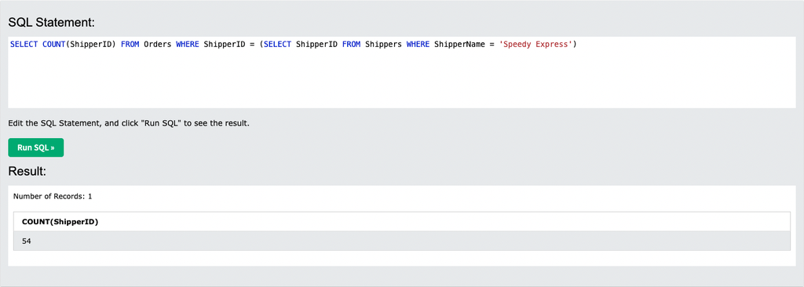

### What is the last name of the employee with the most orders?

```python
# Query 2

SELECT LastName FROM Orders o, Employees e
WHERE o.EmployeeID = e.EmployeeID
GROUP BY o.EmployeeID
HAVING count(o.EmployeeID) = (SELECT COUNT(EmployeeID) as "occurence" from Orders
                              GROUP BY EmployeeID
                              ORDER BY "occurence" DESC limit 1)
```

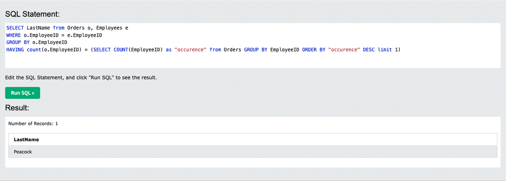

### What product was ordered the most by customers in Germany?

```python
# Query 3

SELECT ProductName, SUM(Quantity) FROM Products p, Orders o, OrderDetails od, Customers c
WHERE Country = "Germany" and c.CustomerID = o.CustomerID and p.ProductID = od.ProductID and o.OrderID = od.OrderID
GROUP BY ProductName
ORDER BY SUM(Quantity)
DESC Limit 1;
```

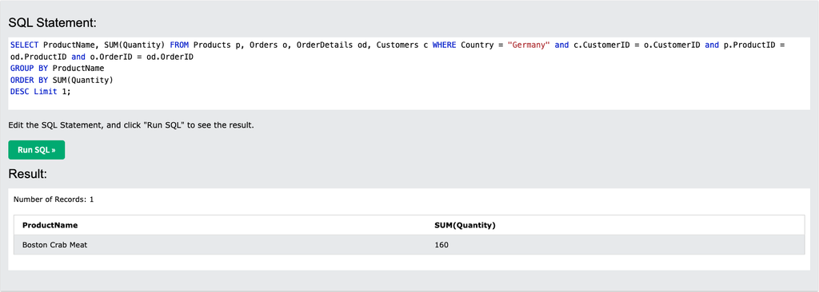